# Data Visualization

Marcus W Beck  
November 5, 2017

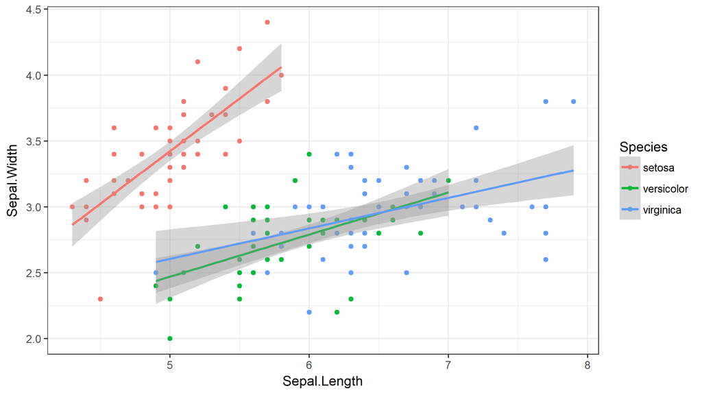

### Lesson outline

A whirlwind tour of data viz

- Simple plots with base R
- `ggplot2`: introduction
- `ggplot2`: data, mapping, aesthetics, and geom layers
- `ggplot2`: themes
- `ggplot2`: additional geoms
- Resources

### Motivation

- You can make some really cool graphs in R

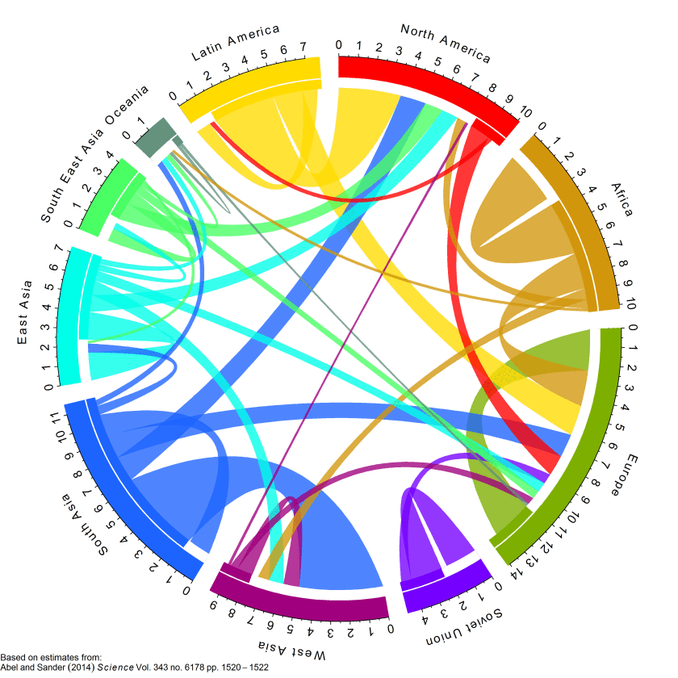

### Motivation

- You can make some really cool graphs in R

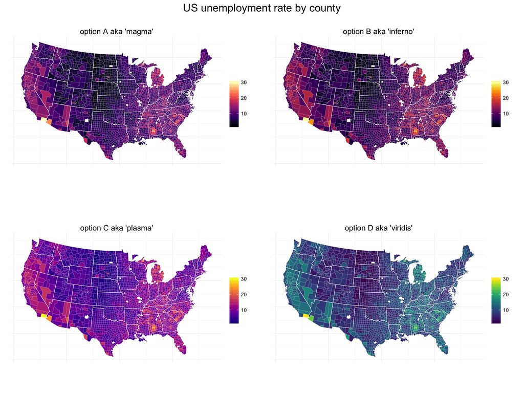

### Motivation

- You can make some really cool graphs in R

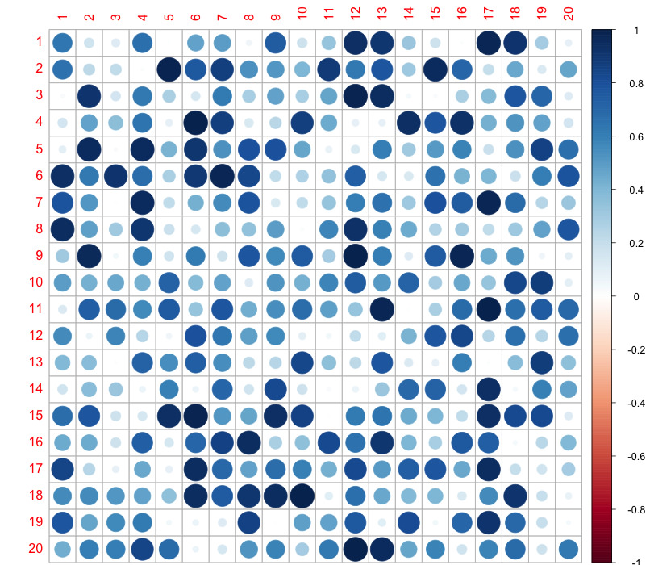

### Motivation

- You can make some really cool graphs in R

3d and interactive: https://blog.plot.ly/post/101360048217/7-plotly-graphs-in-3d-stocks-cats-and-lakes

A CERF example: https://fawda123.github.io/ADOSR/depth_ex

### Simple plots with base R

- Base graphics in R (i.e, those that come with the software) can do most anything for you
- But they're kind of ugly in the default format (bad for pubs)
- Customization is tedious…
- Easy to use for quick, exploratory plots

### Simple plots with base R

- Let's load the `iris` dataset from the [datasets](https://stat.ethz.ch/R-manual/R-devel/library/datasets/html/00Index.html) package
- Measurements on 150 flowers from three species
- *Fisher, R. A. (1936) The use of multiple measurements in taxonomic problems. Annals of Eugenics, 7, Part II, 179–188.*

```r
data(iris)
str(iris)
```

```
'data.frame':   150 obs. of  5 variables:
 $ Sepal.Length: num  5.1 4.9 4.7 4.6 5 5.4 4.6 5 4.4 4.9 ...
 $ Sepal.Width : num  3.5 3 3.2 3.1 3.6 3.9 3.4 3.4 2.9 3.1 ...
 $ Petal.Length: num  1.4 1.4 1.3 1.5 1.4 1.7 1.4 1.5 1.4 1.5 ...
 $ Petal.Width : num  0.2 0.2 0.2 0.2 0.2 0.4 0.3 0.2 0.2 0.1 ...
 $ Species     : Factor w/ 3 levels "setosa","versicolor",..: 1 1 1 1 1 1 1 1 1 1 ...
```

### Simple plots with base R

- Let's load the `iris` dataset from the [datasets](https://stat.ethz.ch/R-manual/R-devel/library/datasets/html/00Index.html) package
- Measurements on 150 flowers from three species
- *Fisher, R. A. (1936) The use of multiple measurements in taxonomic problems. Annals of Eugenics, 7, Part II, 179–188.*

```r
data(iris)
head(iris)
```

```
  Sepal.Length Sepal.Width Petal.Length Petal.Width Species
1          5.1         3.5          1.4         0.2  setosa
2          4.9         3.0          1.4         0.2  setosa
3          4.7         3.2          1.3         0.2  setosa
4          4.6         3.1          1.5         0.2  setosa
5          5.0         3.6          1.4         0.2  setosa
6          5.4         3.9          1.7         0.4  setosa
```

### Simple plots with base R

- The scatterplot can be created with `plot`
- It can be created with one line… `plot(y ~ x, data)`
- This literally says… from the data object, plot the variables y (on the y-axis) against x (on the x-axis)

```r
plot(Sepal.Length ~ Sepal.Width, data = iris)
```

### Simple plots with base R

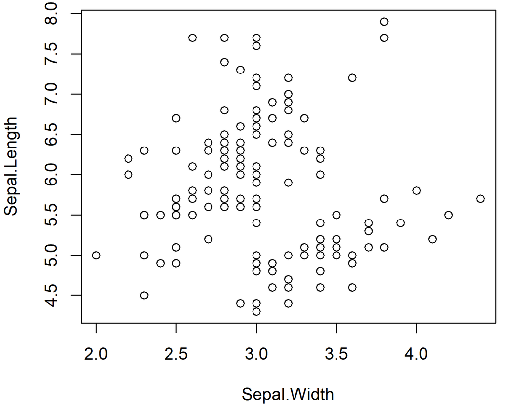

```r
plot(Sepal.Length ~ Sepal.Width, data = iris)
```

### Simple plots with base R

- We can also use alternative notation without using the data argument

```r
plot(iris$Sepal.Width, iris$Sepal.Length)
```

- As compared to…

```r
plot(Sepal.Length ~ Sepal.Width, data = iris)
```

- Note the arrangement of y/x variables in each

### Simple plots with base R

- We can also use alternative notation without using the data argument

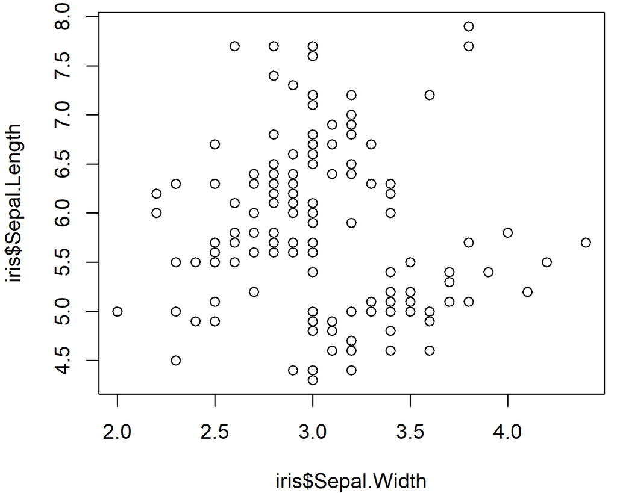

```r
plot(iris$Sepal.Width, iris$Sepal.Length)
```

### Simple plots with base R

- But check out the axis labels…

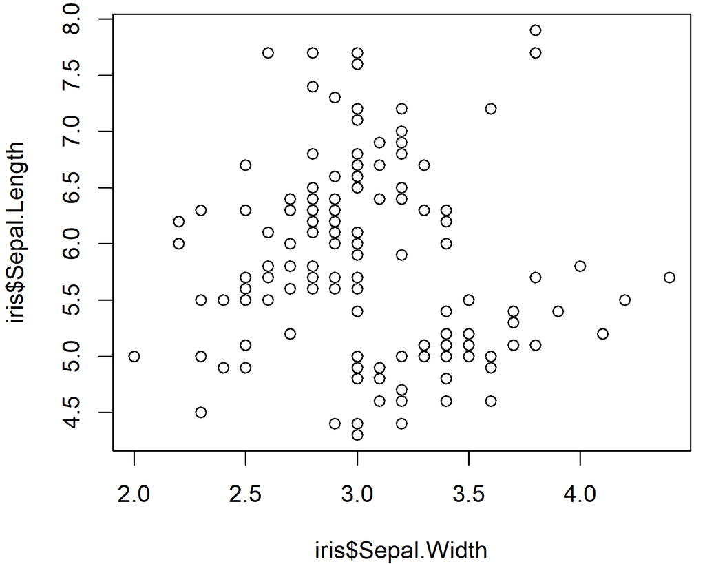

```r
plot(iris$Sepal.Width, iris$Sepal.Length)
```

### Simple plots with base R

- `plot` has lots of optional arguments, called within `plot` or separately using `par`

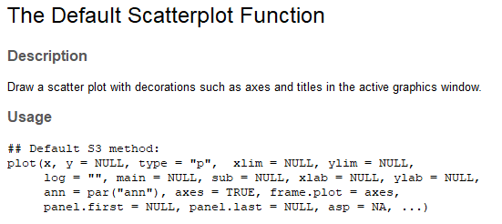

### Simple plots with base R

- Change axis labels, give it a title…

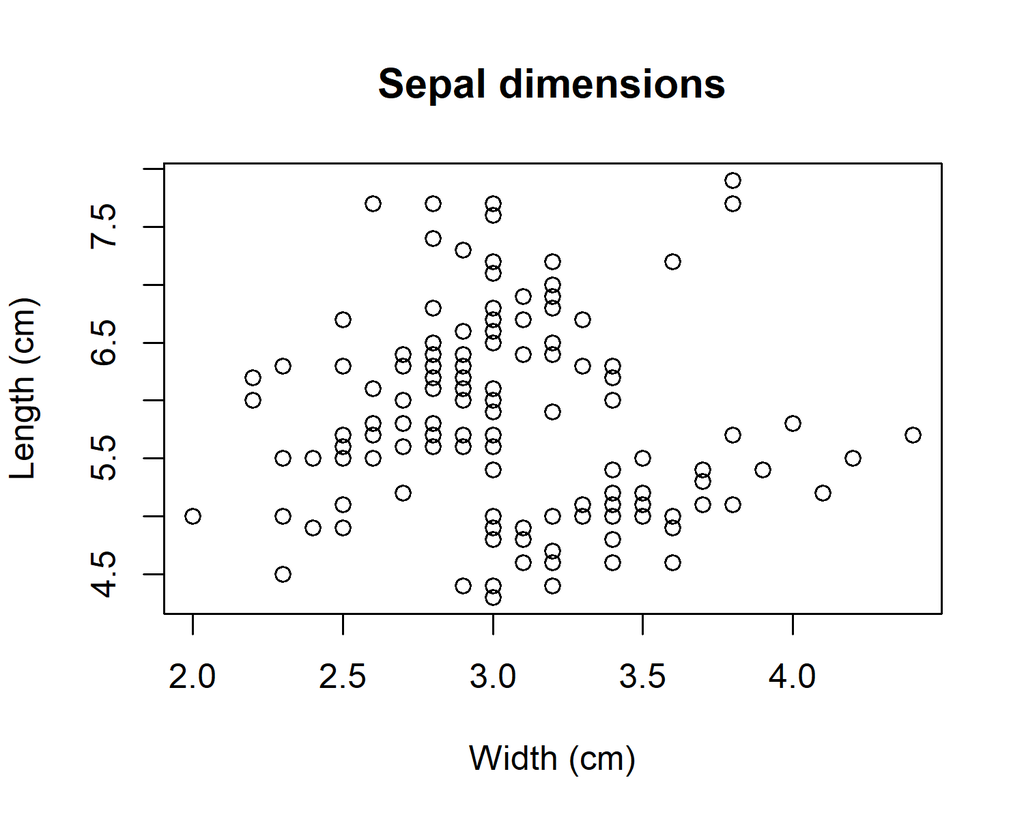

```r
plot(iris$Sepal.Width, iris$Sepal.Length, xlab = 'Width (cm)', ylab = 'Length (cm)', main = 'Sepal dimensions')
```

### Simple plots with base R

- The plot margins are too big, let's change that

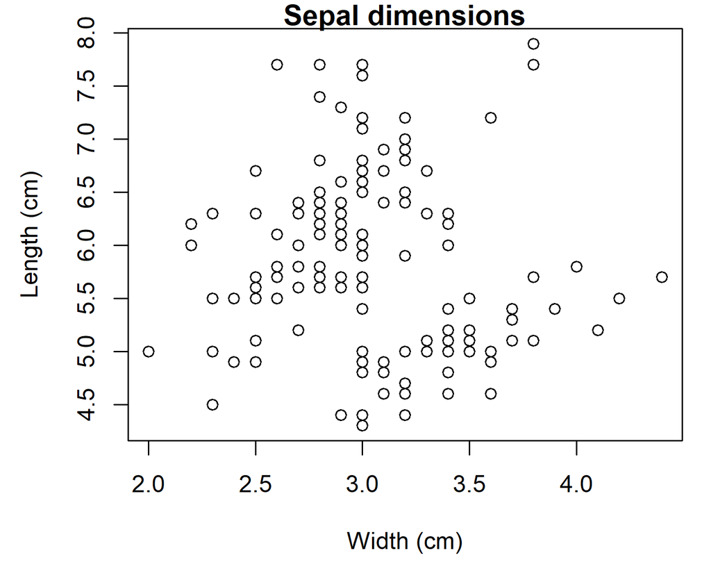

```r
par(mar = c(4.5, 4.5, 1, 1))
plot(iris$Sepal.Width, iris$Sepal.Length, xlab = 'Width (cm)', ylab = 'Length (cm)', main = 'Sepal dimensions')
```

### Simple plots with base R

- Other base plot functions - bar plots

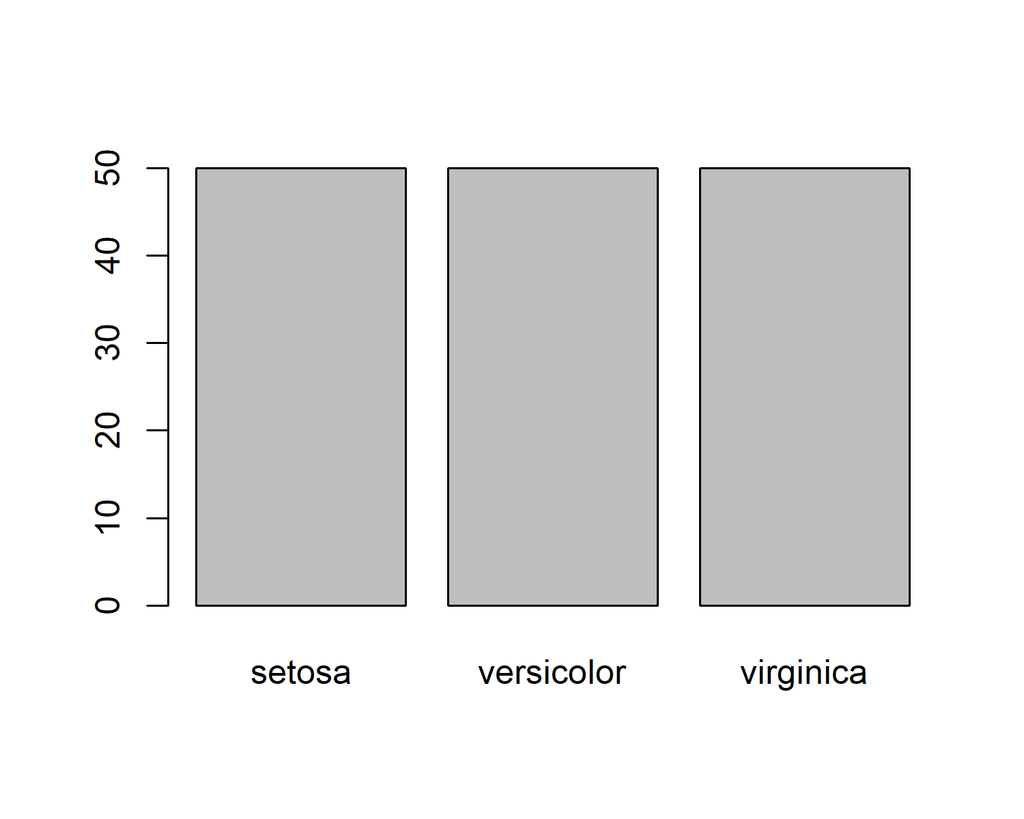

```r
barplot(table(iris$Species))
```

### Simple plots with base R

- Other base plot functions - histogram

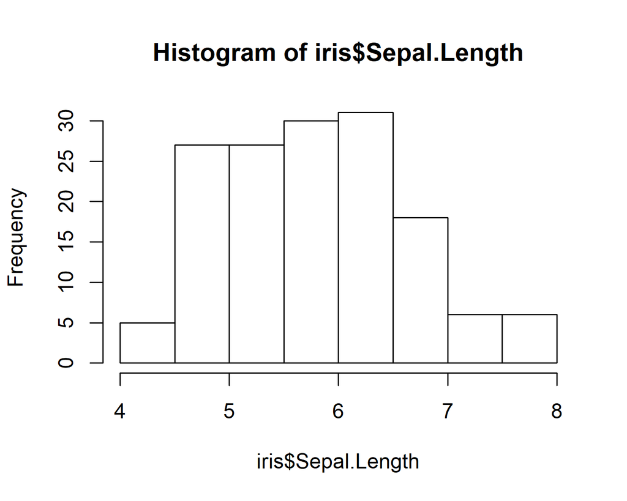

```r
hist(iris$Sepal.Length)
```

### Simple plots with base R

- Other base plot functions - box plots

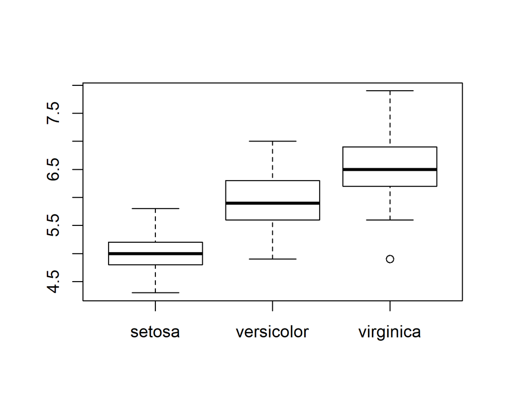

```r
boxplot(Sepal.Length ~ Species, data = iris)
```

### Simple plots with base R

- Other base plot functions - paired scatter plots

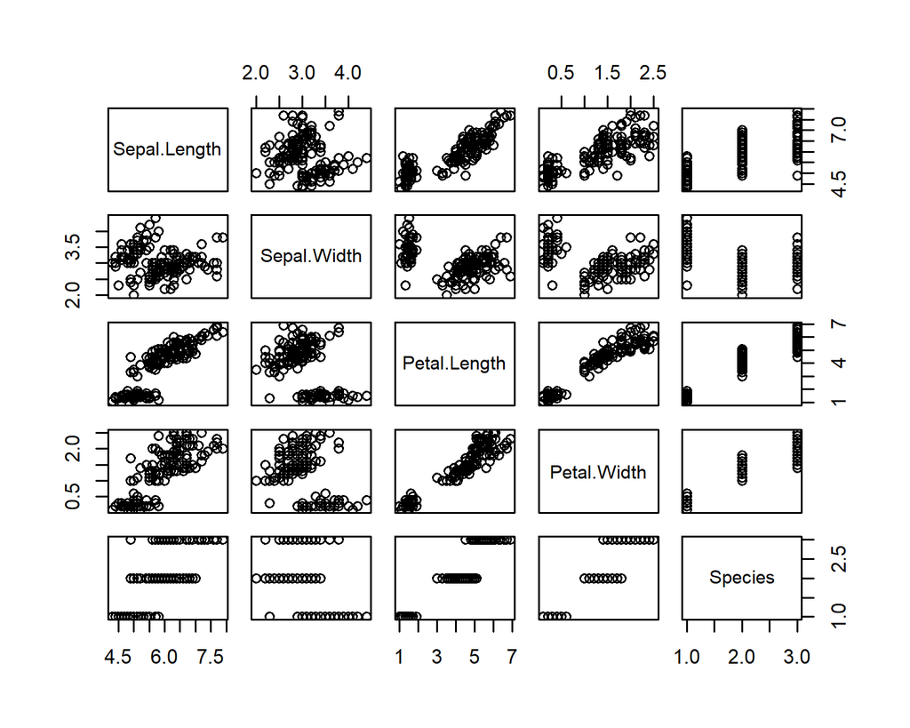

```r
pairs(iris)
```

### Exercise 1

- Using the `iris` dataset, make a scatterplot of petal length (y axis) vs petal width (x-axis)
- Give it appropriate axis labels and a title
- Change the point type, size, and color (see `?plot` and `?par`)

### ggplot2: introduction

- Base graphics are okay for exploratory stuff
- ggplot2 is meant to improve on base by linking the graph components following a **grammar of graphics** - like parts of speech
- Makes thinking, reasoning, and communicatings graphics easier
- Start with a foundational component to add additional pieces

[figure not shown]

### ggplot2: introduction

- We'll start by installing and loading [tidyverse](https://www.tidyverse.org/), which includes ggplot2 (you should have this from the earlier session)

```r
install.packages('tidyverse')
library(tidyverse)
```

To verify it's loaded…

```r
loadedNamespaces()
```

```
 [1] "Rcpp"       "highr"      "cellranger" "compiler"   "plyr"
 [6] "bindr"      "methods"    "forcats"    "utils"      "tools"
[11] "grDevices"  "digest"     "lubridate"  "jsonlite"   "evaluate"
[16] "tibble"     "nlme"       "gtable"     "lattice"    "pkgconfig"
[21] "rlang"      "psych"      "parallel"   "haven"      "bindrcpp"
[26] "xml2"       "httr"       "dplyr"      "stringr"    "knitr"
[31] "graphics"   "datasets"   "stats"      "hms"        "grid"
[36] "glue"       "base"       "R6"         "readxl"     "foreign"
[41] "readr"      "modelr"     "reshape2"   "tidyr"      "purrr"
[46] "ggplot2"    "magrittr"   "scales"     "rvest"      "assertthat"
[51] "mnormt"     "tidyverse"  "colorspace" "labeling"   "stringi"
[56] "lazyeval"   "munsell"    "broom"
```

### ggplot2: data, mapping, aesthetics, and layers

- The general concepts of `ggplot2` revolve around the **data**, plot **layers**, **aesthetics**, and **mapping**
- This is by far the biggest hurdle in learning `ggplot`
- Just remember, the **aesthetics** are parts of the plot **layers** that **map** the variables in the **data** to the plot
- We'll demonstrate when this system breaks down to understand how it works

### ggplot2: data, mapping, aesthetics, and layers

- We'll start with a very simple scatterplot with the iris data

```r
head(iris)
```

```
  Sepal.Length Sepal.Width Petal.Length Petal.Width Species
1          5.1         3.5          1.4         0.2  setosa
2          4.9         3.0          1.4         0.2  setosa
3          4.7         3.2          1.3         0.2  setosa
4          4.6         3.1          1.5         0.2  setosa
5          5.0         3.6          1.4         0.2  setosa
6          5.4         3.9          1.7         0.4  setosa
```

### ggplot2: data, mapping, aesthetics, and layers

- All ggplot plots start with the `ggplot` function
- It will typically need two pieces of information, the **data** and how the data are **mapped** to the plot **aesthetics**

```r
ggplot(data = iris, aes(x = Sepal.Width, y = Sepal.Length))
```

- This says, make a `ggplot` object for the iris **data**, where the variables Sepal.Width and Sepal.Length are **mapped** to the **x** and **y** aesthetics

### ggplot2: data, mapping, aesthetics, and layers

- The `aes` function defines the mapping of variables to aesthetics

```r
aes(x = Sepal.Width, y = Sepal.Length)
```

```
* x -> Sepal.Width
* y -> Sepal.Length
```

### ggplot2: data, mapping, aesthetics, and layers

- What happens when we run this function?

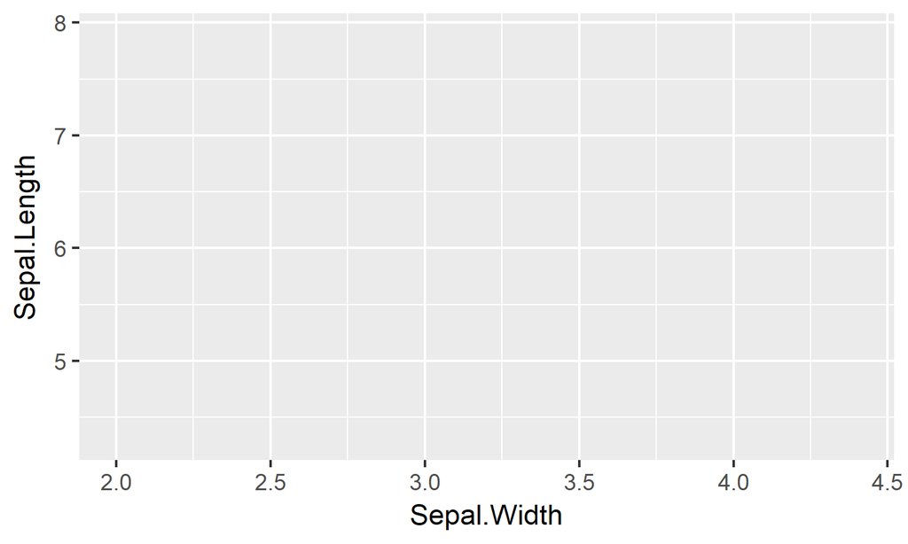

```r
ggplot(data = iris, aes(x = Sepal.Width, y = Sepal.Length))
```

- We get an empty plot - this is our foundation

### ggplot2: data, mapping, aesthetics, and layers

- We add plot elements to the base plot using `+`

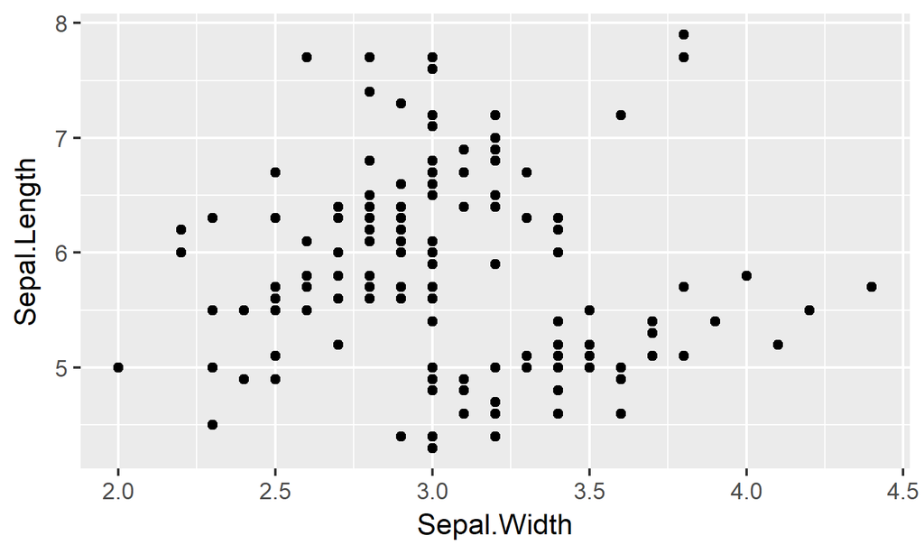

```r
ggplot(data = iris, aes(x = Sepal.Width, y = Sepal.Length)) +
  geom_point()
```

### ggplot2: data, mapping, aesthetics, and layers

- We add plot elements to the base plot using `+`

```r
ggplot(data = iris, aes(x = Sepal.Width, y = Sepal.Length)) +
  geom_point()
```

- “geoms” are plot layers that put the mapping of aesthetics in action
- There are many geoms: http://ggplot2.tidyverse.org/reference/

### ggplot2: data, mapping, aesthetics, and layers

- We can swap out any geom that uses x/y aesthetics

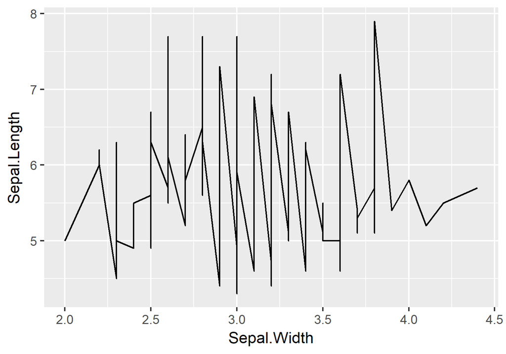

```r
ggplot(data = iris, aes(x = Sepal.Width, y = Sepal.Length)) +
  geom_line()
```

### ggplot2: data, mapping, aesthetics, and layers

- We can swap out any geom that uses x/y aesthetics

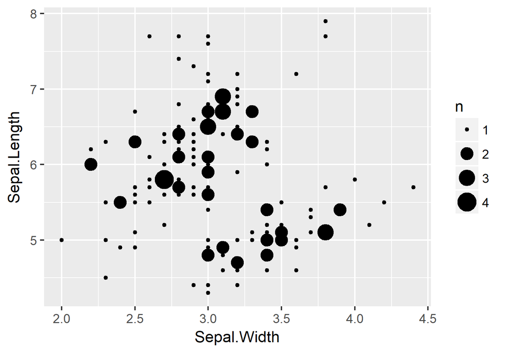

```r
ggplot(data = iris, aes(x = Sepal.Width, y = Sepal.Length)) +
  geom_count()
```

### ggplot2: data, mapping, aesthetics, and layers

- We can swap out any geom that uses x/y aesthetics

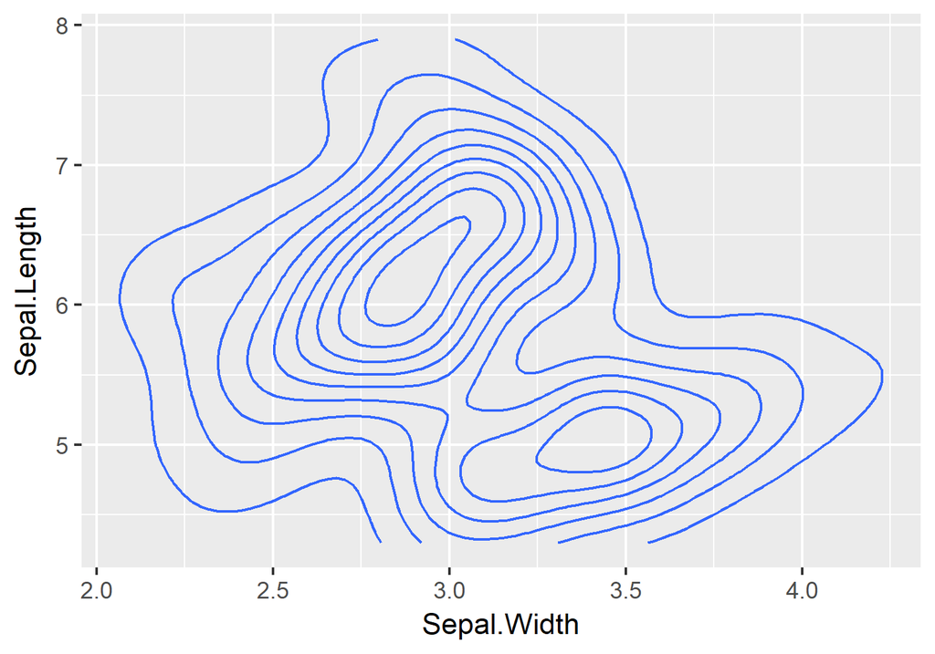

```r
ggplot(data = iris, aes(x = Sepal.Width, y = Sepal.Length)) +
  geom_density_2d()
```

### ggplot2: data, mapping, aesthetics, and layers

- We can swap out any geom that uses x/y aesthetics

```r
ggplot(data = iris, aes(x = Sepal.Width, y = Sepal.Length)) +
  geom_linerange()
```

```
Error: geom_linerange requires the following missing aesthetics: ymin, ymax
Execution halted
```

- Oh snap, what happened?

### ggplot2: data, mapping, aesthetics, and layers

- We can swap out any geom that uses x/y aesthetics

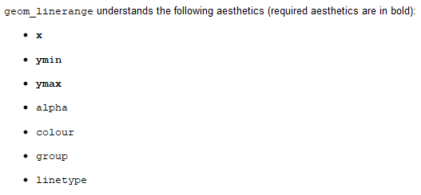

```r
?geom_linerange
```

### ggplot2: data, mapping, aesthetics, and layers

- Let's return to the `geom_point` layer, what are its aesthetics?

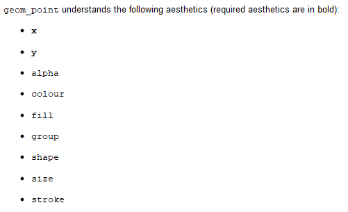

```r
?geom_point
```

### ggplot2: data, mapping, aesthetics, and layers

- Let's add some more aesthetics

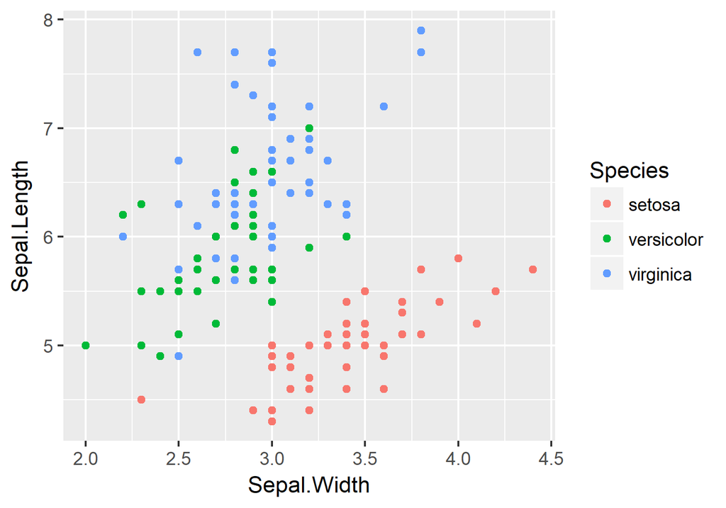

```r
ggplot(data = iris, aes(x = Sepal.Width, y = Sepal.Length,
                        colour = Species)) +
  geom_point()
```

### ggplot2: data, mapping, aesthetics, and layers

- Let's add some more aesthetics

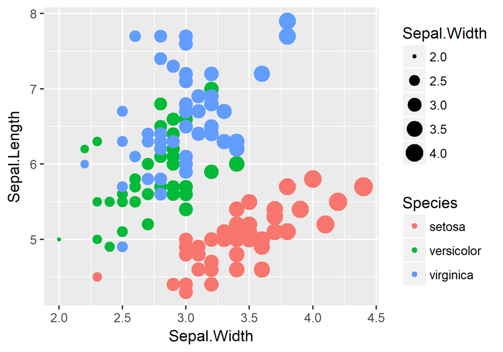

```r
ggplot(data = iris, aes(x = Sepal.Width, y = Sepal.Length,
                        colour = Species, size = Sepal.Width)) +
  geom_point()
```

### ggplot2: data, mapping, aesthetics, and layers

- Let's add some more aesthetics, what's the difference?

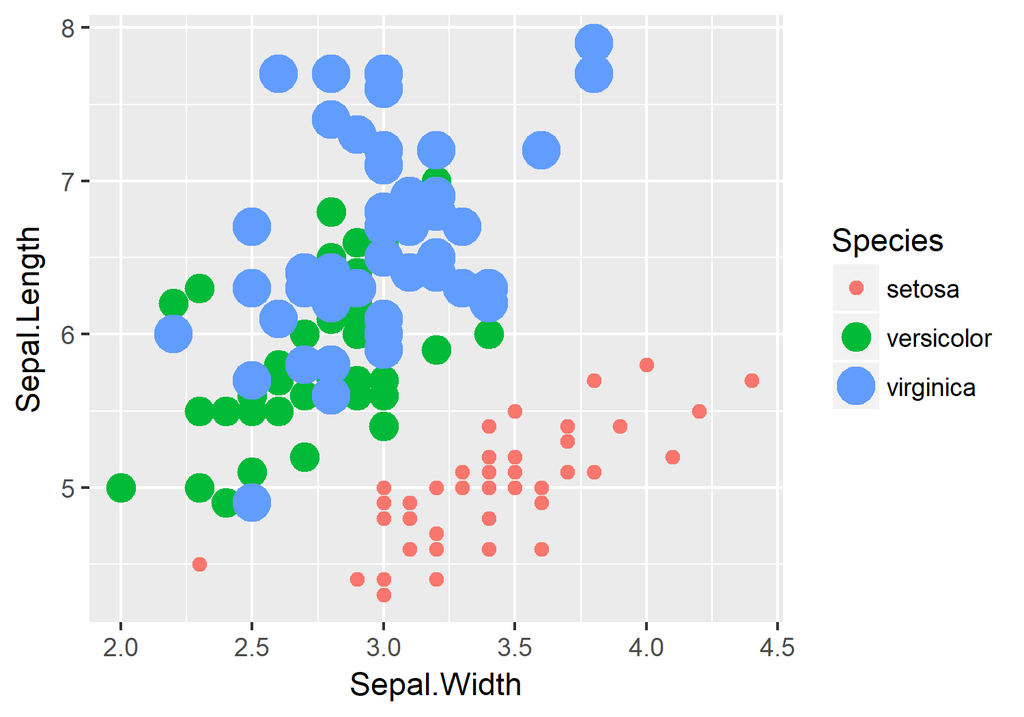

```r
ggplot(data = iris, aes(x = Sepal.Width, y = Sepal.Length,
                        colour = Species, size = Species)) +
  geom_point()
```

### ggplot2: data, mapping, aesthetics, and layers

- We'll use this plot going forward

```r
ggplot(data = iris, aes(x = Sepal.Width, y = Sepal.Length,
                        colour = Species)) +
  geom_point()
```

Let's save it as an object:

```r
p <- ggplot(data = iris, aes(x = Sepal.Width, y = Sepal.Length,
                             colour = Species)) +
  geom_point()
class(p)
```

```
[1] "gg"     "ggplot"
```

### ggplot2: data, mapping, aesthetics, and layers

- Let's modify the plot a bit

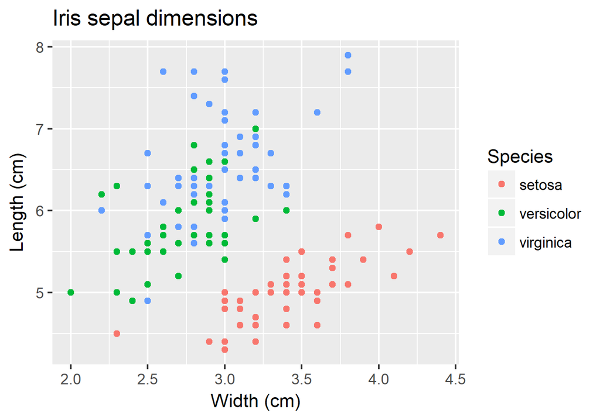

```r
p <- p + xlab('Width (cm)') + ylab('Length (cm)') +
  ggtitle('Iris sepal dimensions')
p
```

### ggplot2: data, mapping, aesthetics, and layers

- Let's modify the plot a bit

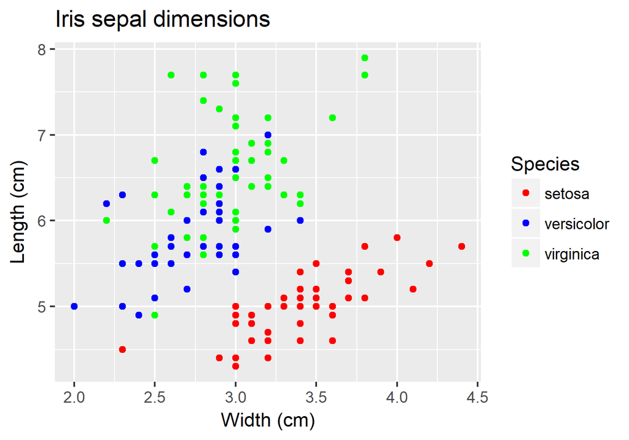

```r
p <- p + scale_colour_manual(values = c('red', 'blue', 'green'))
p
```

### ggplot2: data, mapping, aesthetics, and layers

- What does our plot object contain?

```r
ggplot(data = iris, aes(x = Sepal.Width, y = Sepal.Length,
                             colour = Species)
       ) +
  geom_point() +
  xlab('Width (cm)') + ylab('Length (cm)') +
  ggtitle('Iris sepal dimensions') +
  scale_colour_manual(values = c('red', 'blue', 'green'))
```

### ggplot2: themes

- We can further modify ggplot objects using `theme`
- This is for all non-data elements of a plot, such as:
  - fonts
  - legend position
  - plot and panel backgrounds
  - axis tick spacing
  - grid lines
  - etc.

### ggplot2: themes

- Let's change the legend position

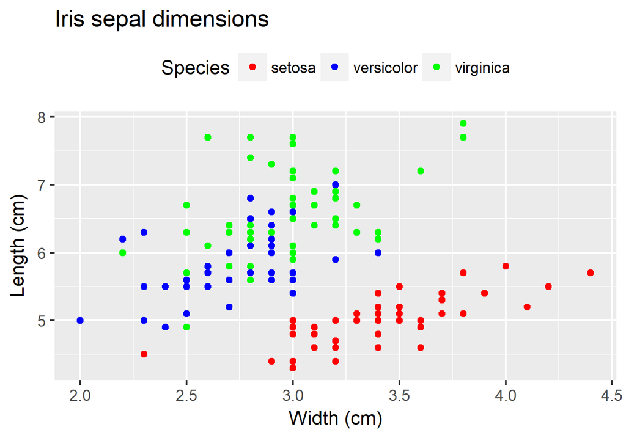

```r
p <- p + theme(legend.position = 'top')
p
```

### ggplot2: themes

- Let's remove the grid lines

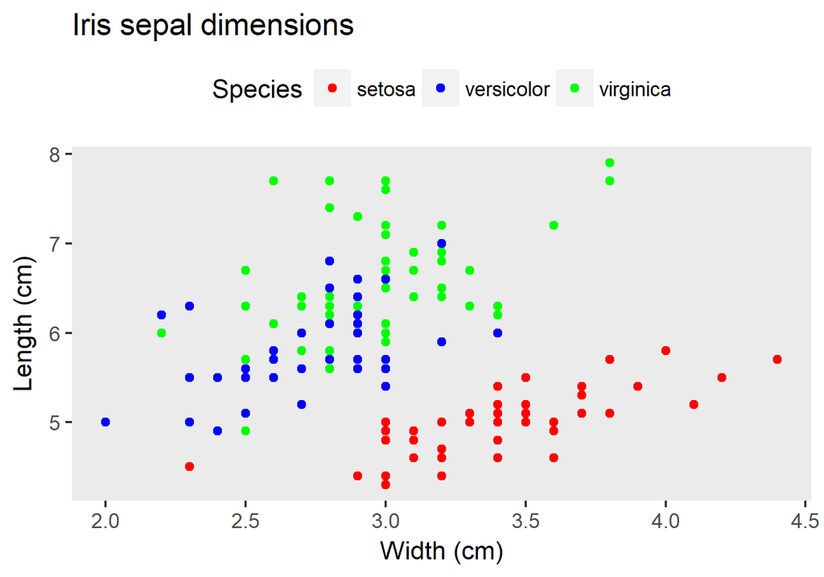

```r
p <- p + theme(
  panel.grid.major = element_blank(),
  panel.grid.minor = element_blank()
)
p
```

### ggplot2: themes

- Let's change the plot background color

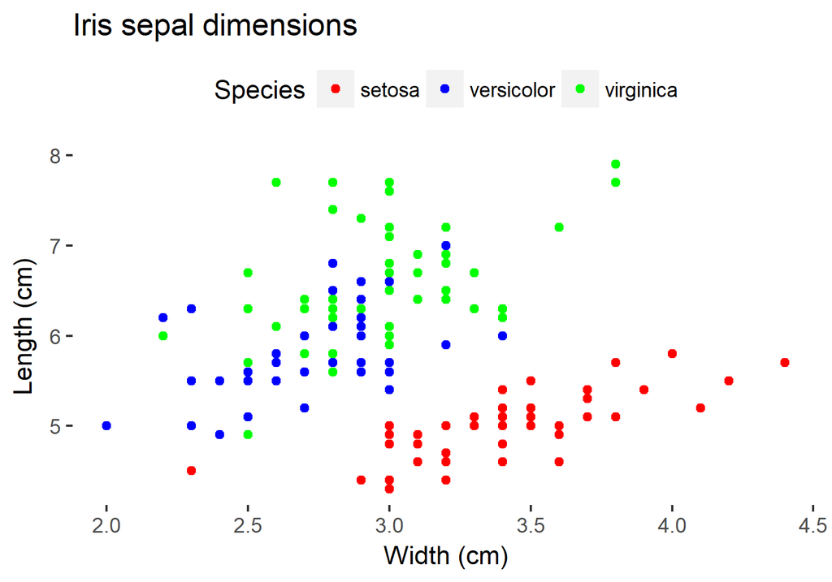

```r
p <- p + theme(panel.background = element_rect(fill = 'white'))
p
```

### ggplot2: themes

- How many theme options are there?

```r
?theme
```

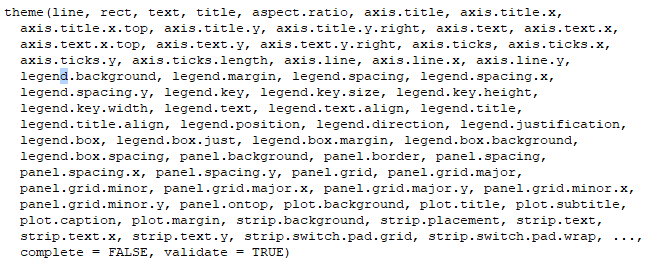